# What is cultural data?

Social and Cultural Analytics (7AAVBCS5)

Dr Mark J. Hill · mark.j.hill@kcl.ac.uk

2026-10-05

## Lecture Plan

**Part I: Substantive overview**

- Quantifying culture and its implications

**Part II: Group work**

- Describing data

**Part III: Live coding**

- Lists and arrays (numbers, text, True/False)
- Indexing and slicing
- Dictionaries
- List repetition with `*`, and f-strings
- Basic descriptive stats
  - Min, max, sum, mean, median, standard deviation
- Comparisons and `if`

This week we continue to focus on the basics of coding, but begin to think about how coding can be used as an approach to cultural data analysis.

This will involve substantive reflections on what cultural data is, what data looks like, and performing useful operations on **lists and arrays**.

You will be introduced to some of the key ideas involved in coding for research purposes, and begin with good practices that will stand you in good stead in your academic work.

# Quantifying Culture

## Quantifying culture

> “In general terms, quantification entails an act of translation: it expresses phenomena, characteristics or states of affairs in a general, abstract and universally accessible language – that of mathematics. This can be done by measurement or by transforming qualitative judgements, insights and observations into numeric values. Quantifications reduces a complex and confusing world to the standardized language of numbers…”

> (Mau 2019, p. 13)

But what does it mean to translate culture and society into numbers?

[figure not shown]

## From experts to data

- Quantifying culture emerges in the 19th century following the Enlightenment project
- Position that (objective) data can be trusted more than (subjective) humans
- Used to challenge authority and support human progress
- “Numerical accountability, with its promise of transparency and rule-bound objectivity […] gained prominence in conditions of distrust about experts.” (Wiggins and Jones, p. 17)

[figure not shown]

## Social Physics and l’homme moyen

Developed by Belgian astronomer **Adolphe Quetelet** (1796–1874)

Patterns in social phenomena can be statistically analysed to identify average population characteristics (birth of statistics in social science)

- **Crime**: stable over time and shaped by social and economic factors rather than individual morality.
- **Marriage**: followed cultural and social patterns, differing across places and classes, rather than personal decision.
- **BMI**: the idea of the “Average Man,” shaping modern notions of what is considered normal.

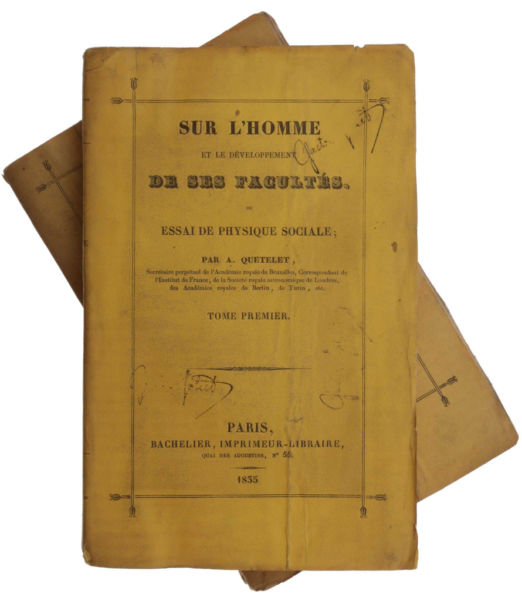

## L’homme moyen?

- There’s a risk in drawing conclusions from these quantified social traits
- “Average man” concept obscures individual diversity
- Misused in classifying people and groups (e.g., Francis Galton, eugenics, and racist theories)
- Data was seen as **laws** of society instead of **descriptions** of society

Sound familiar?

[figure not shown]

## Data is made, not found

> “The study of data threatened to displace other forms of expertise, from science to shop floors to the drug store. Rather than lush descriptions of countryside, a counting of flora and fauna. Rather than an ethical discussion of values, an attempt to model the effects of a given policy quantitatively. Rather than the gruesome reality of death, tables of mortality statistics. Rather than expertise about potential desires of consumers, the collection and analysis of every purchase. Rather than the clinical experience of individual physicians with a drug, randomized trials to gauge effectiveness and safety. Rather than a judgement of the character of a student applying to college, the use of standardized tests to supply an ‘objective’ measurement.”

> (Wiggins and Jones, p. 22)

## Numbers represent concepts

These are numerical constructs aimed at **measuring concepts**. This means there is subjectivity in datafication

- Numerical measurements are created to represent concepts
- These measurements do not represent objective reality
- Data collection reflects choices, and often societal values and biases

Data is frequently used to make claims about social reality, but there’s a risk of conforming social reality to fit numerical descriptions

Always question whether measurements align with concepts you’re interested in.

## Critical issues in cultural data

- **Selection Bias**
  - Whose culture is recorded, preserved, digitised? *(example)*
- **Quality and Technical Challenges**
  - OCR, metadata, format obsolescence *(example)*
- **Algorithmic Bias**
  - Training data amplifies prejudices *(example)*
- **Access and Power Dynamics**
  - Paywalls, API restrictions, geographic fragmentation *(example)*
- **Indigenous Data Sovereignty**
  - FAIR vs CARE principles *(example)*

## The five dimensions of context

Every dataset records some dimensions and not others. The chapter gives us a checklist:

| Dimension | Unit of analysis | Typical data type in Python |
| --- | --- | --- |
| **Semiotic** | the sign | `str` – words, tokens, labels |
| **Temporal** | the timestamp | dates, or `int` years |
| **Spatial** | the coordinate | `float` pairs, place names |
| **Social** | the agent attribute | categories – role, class, gender |
| **Relational** | the edge | pairs of things that are linked |

Hill, “Contextual Analytics”, §3 and Table 1

# Interrogating datasets

Group activity

## Datasets, analysis, interpretation

**Datasets**

A collection of data, ready for analysis

Examples: responses to a survey; frequencies of all the words in a set of books; house prices in a city

**Analysis**

Identifying, quantifying and interpreting patterns in a dataset

… patterns that can be quantified, or measured

**Interpretation**

What does the pattern mean?

What does it tell us about the world?

## Data inspection

Choose a dataset from the list in:

- https://msuintrodhfall2020.hcommons.org/datasets/
- https://openhumanitiesdata.metajnl.com/articles/

**Group activity – describe your data**

- What does the dataset consist of?
- What format is the dataset in?
- What variables (and maybe types of variables) can you see in it?
- **Which of the five dimensions are present, and which are missing?**
- What sort of questions could you answer by analysing the dataset?

You will be asked to present back your main findings

# Review

## What we’ve learned so far…

- Python as a calculator
- Data types (`int`, `float`, `str`, `bool`)
- How to assign variables
- Manipulating/operating on variables
- Notebook basics

**This week:**

- Lists, arrays and basic descriptive analyses
- Dictionaries
- Comparisons and `if`

# Lists and arrays in Python

## Collections

Last week each variable held **one** value. This week, one variable holds **many**.

Python gives you two things where R gives you one:

|  | R | Python |
| --- | --- | --- |
| Ordered collection, mixed types allowed | *(list)* | **`list`** |
| Ordered collection, all one type, does maths on all of it at once | **vector** | **numpy array** |

If you have seen R before: `c(18, 21, 30)` is not a Python list. It is a numpy array.

## Lists

An ordered collection of items. Created with square brackets.

```python
ages = [18, 21, 30, 24, 22, 22]
ages
```

```
[18, 21, 30, 24, 22, 22]
```

Key characteristics:

- **Ordered** – items have positions
- **Mixed types allowed** – unlike an R vector
- **One-dimensional** – a single sequence of values

## Position

Python counts from **zero**. R counts from one.

```
List:      [18,  21,  30,  24,  22]
Position:    0    1    2    3    4
```

```python
ages = [18, 21, 30, 24, 22]
print(ages[0])   # the first item
print(ages[2])   # the third item
print(ages[-1])  # the last item
```

```
18
30
22
```

## Slicing

Take a range of positions with a colon. The **start is included, the end is not**.

```python
ages = [18, 21, 30, 24, 22]
print(ages[0:3])   # positions 0, 1, 2 -- not 3
print(ages[:2])    # from the start
print(ages[2:])    # to the end
```

```
[18, 21, 30]
[18, 21]
[30, 24, 22]
```

`ages[0:3]` gives you **three** items, not four. The end position is excluded.

## Changing and growing a list

```python
cities = ["London", "Manchester", "Rome"]
cities.append("Lima")        # add to the end
cities[0] = "Edinburgh"      # replace an item
print(cities)
print(len(cities))           # how many items
```

```
['Edinburgh', 'Manchester', 'Rome', 'Lima']
4
```

## Why this matters

Instead of:

```python
age1 = 18
age2 = 21
age3 = 30
age4 = 24
age5 = 22
```

Use a collection:

```python
ages = [18, 21, 30, 24, 22]
```

and then work on the whole thing at once.

- One name for many values
- Operations can apply to all of it
- The foundation of the data frames we meet in Week 3

## The trap: lists do not do maths

```python
ages = [18, 21, 30]
ages * 2
```

```
[18, 21, 30, 18, 21, 30]
```

In R, `ages * 2` doubles every value. In Python, `ages * 2` **repeats the list**. No error.

## Arrays do do maths

```python
import numpy as np

temperatures_c = np.array([20, 25, 18, 30])
temperatures_f = (temperatures_c * 9 / 5) + 32
print(temperatures_f)

hot_days = temperatures_c > 25
print(hot_days)
```

```
[68.  77.  64.4 86. ]
[False False False  True]
```

Operations apply **element-wise**, automatically. This is what R’s vectors do, and it is much faster than looping.

## Arrays force one type

```python
import numpy as np
np.array([1, 2, True, "word"])
```

```
array(['1', '2', 'True', 'word'], dtype='<U21')
```

Everything became text. Arrays **coerce** to a single type; the order is `text > number > True/False`.

```python
print(np.array([True, False, 1]))   # True/False become 1 and 0
```

```
[1 0 1]
```

## Lists vs arrays

| Feature | List | Array |
| --- | --- | --- |
| Element types | Mixed allowed | All the same (coerced) |
| Structure | Flat, one-dimensional | Flat, or multi-dimensional |
| Creation | `[1, 2, 3]` | `np.array([1, 2, 3])` |
| `* 2` does | repeats the list | doubles every value |
| Use | general-purpose collections | data analysis, calculations |

## Dictionaries

A list looks things up by **position**. A dictionary looks them up by **name**.

```python
student = {"name": "Sarah", "age": 21, "enrolled": True}
print(student["name"])
student["courses"] = ["History", "Stats"]
print(student.keys())
```

```
Sarah
dict_keys(['name', 'age', 'enrolled', 'courses'])
```

## Describing data

```python
import numpy as np

ages = np.array([18, 21, 30, 24, 22, 22])
print("count  ", len(ages))
print("min    ", ages.min())
print("max    ", ages.max())
print("sum    ", ages.sum())
print("mean   ", ages.mean())
print("median ", np.median(ages))
print("std    ", ages.std())
```

```
count   6
min     18
max     30
sum     137
mean    22.833333333333332
median  22.0
std     3.670452590924207
```

## Building text

```python
year = 1945
print(f"WW2 ended in {year} when the Allies won.")

name = "Alice"
print(f"{name} has {len(name)} letters")
```

```
WW2 ended in 1945 when the Allies won.
Alice has 5 letters
```

Anything in `{curly braces}` inside an `f"..."` string gets replaced by its value.

# Comparisons and `if`

## Comparisons, again

From last week:

```python
print(3 == 4)
print(3 != 4)
print(2 <= 2)
print("London" == "london")
```

```
False
True
True
False
```

Comparisons produce `True` or `False`. That is what makes decisions possible.

## Making a decision

```python
temperature = 20

if temperature > 10:
    print("go for a run")
else:
    print("stay at home")
```

```
go for a run
```

- The line ends with a **colon**
- The block underneath is **indented** – four spaces
- Indentation is not decoration; it is how Python knows what belongs to the `if`

## More than two outcomes

```python
mark = 65

if mark >= 70:
    print("First")
elif mark >= 60:
    print("2:1")
elif mark >= 50:
    print("2:2")
else:
    print("Fail")
```

```
2:1
```

`elif` is “else if”. Python checks each in order and stops at the first true one.

## Combining conditions

```python
age = 55

if age >= 50 and age <= 60:
    print("not young but also not old")

year = 1560
if year >= 1400 and year <= 1780:
    print("Early modern")
```

```
not young but also not old
Early modern
```

`and`, `or`, `not` – in words, not symbols.

# How not to lose an afternoon

## Notebooks remember things you deleted

Cells run in the order **you click them**, not top to bottom.

So a variable can still exist after you delete the cell that created it – and your notebook will work for you but fail for everyone else.

Before you submit anything: **Restart and Run All**

If it does not survive that, it is broken.

## Four errors you will see this term

| Error | Means | Usually |
| --- | --- | --- |
| `NameError` | I have no variable with that name | typo, or the cell that made it never ran |
| `SyntaxError` | I cannot even read this line | missing `:`, bracket, or quote |
| `IndentationError` | the spacing does not make sense | mixed tabs and spaces |
| `TypeError` | you tried something on the wrong type | `"7" + 7` |

**Read the last line first.** Everything above it is machinery.

## When to use what

- **List** – a collection of things, possibly of different kinds
- **Array** – measurements you want to calculate with (temperatures, ages, scores)
- **Dictionary** – things you look up by name
- Time series, survey responses, any column of the same type -> array
- Mathematical/statistical operations -> array

**Key takeaways:**

1. Lists: ordered, mixed types allowed, positions start at **0**
2. Arrays: one type, and maths applies to every element at once
3. `list * 2` repeats; `array * 2` doubles
4. Dictionaries: look up by name, not position
5. Slices exclude their end point

## Before next week

1. Complete `w02_worksheet.ipynb` in the workshop
2. Read Hill, “Contextual Analytics”, §3 (the five dimensions)

**Note**

The quiz in next week’s lecture covers **this week’s** material.